# Climate Futures

Amber Runyon

3/23/2022

## Climate Futures

When trying to adapt to a changing climate, with all the inherent uncertainties about how the future may play out, resource managers often turn to scenario planning as a tool. Managers use scenario planning to explore plausible ways the climate may change, allowing them to work with climate change uncertainty rather than being paralyzed by it. Once identified, scenarios of the future are used to develop proactive measures to prepare for and adapt to scenarios of change. A key part of scenario planning is generating a list of potential future climates we may experience. This script uses methods described in Lawrence et al. (2020) and [Runyon et al. (2019)](https://escholarship.org/uc/item/76p7m8rz) to identify divergent, plausible climate futures for selected national parks.

## Steps to run the code

This code uses CMIP5 gloabal climate projections (2005-2099) downscaled by the MACA (Multivariate Adaptive Constructed Analogs) method (Abatzoglou and Brown 2012) with the METDATAv2 (Abatzoglou 2011) observational dataset as training data. (See https://climate.northwestknowledge.net/MACA/MACAmethod.php for details). The historical observational data used is GridMET, which is the training data used for the MACA downscaleing (Abatzoglou 2013, https://climate.northwestknowledge.net/MACA/MACAtrainingdata.php).

To run this code, you must first enter the 4-letter code for the park unit you wish to plot (e.g., Rocky Mountain National Park is ROMO) and the location where you would like this data saved once it is downloaded. The following chunk of code will then download the historical and projected climate data from the MACA and GridMET datasets. The projected data is daily for 20 GCMs and 2 RCPs, so it may take a second.

```
## [1] "ROMO_historical.csv  File exists. Not downloaded"
```

```
## [1] 1
```

```
## [1] "ROMO_future.csv  File exists. Not downloaded"
```

```
## [1] 1
```

## Select divergent climate futures

Note CCRP has produced an R package that conducts all of the following steps. It will be released in early-Summer 2022.

| GCM | CF |
| --- | --- |
| HadGEM2-ES365.rcp85 | Hot Dry |
| MIROC-ESM-CHEM.rcp85 | Hot Wet |
| MRI-CGCM3.rcp45 | Warm Dry |
| MRI-CGCM3.rcp85 | Warm Wet |

These models are plotted relative to the other models.

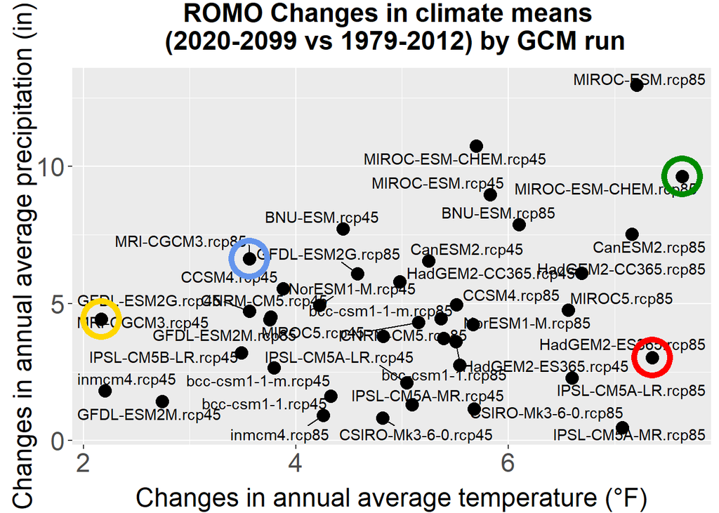